# Introduction to Python

### part 5 Scipy

- high-level Scientific computing
- 內插、積分、最佳化、圖片處理、統計、特殊函數
- 等同於C的GSL(GNU Scientific Library for C and C++) 或 Matlab's toolboxes

#### 2021/5/3

#### 參考資料

- [Scipy](https://www.scipy.org/)
- [Scipy Lecture Notes](http://www.scipy-lectures.org/index.html)
- [SciPy Cookbook](http://scipy-cookbook.readthedocs.io/index.html)

# Scipy

`import scipy as sp`

### 物理常數

`import scipy.constants as cont`

- [Constants](https://docs.scipy.org/doc/scipy/reference/constants.html) https://docs.scipy.org/doc/scipy/reference/constants.html
- [Particle Data Group](http://pdg.lbl.gov/)，http://pdg.lbl.gov/

### 特殊函數

`import scipy.special as special`

- [Special Function](https://docs.scipy.org/doc/scipy/reference/special.html)

```python
% matplotlib inline
import scipy.constants as cont
import scipy.special as special

g = cont.g
h = cont.h
k = cont.k
c = cont.c

print(g, h, k, c, sep='\n')
print(special.jv(1,1)) # Bessel function
```

```
9.80665
6.62607004e-34
1.38064852e-23
299792458.0
0.44005058574493355
```

### 積分

`import scipy.integrate as integrate`

- `scipy.integrate.quad` : Compute a definite integral.
- `scipy.integrate.nquad` : Integration over multiple variables.

https://docs.scipy.org/doc/scipy/reference/integrate.html

https://docs.scipy.org/doc/scipy/reference/tutorial/integrate.html

$$\int_{0}^{2} (3x^2+1) dx$$

```python
from scipy.integrate import quad

def f(x):
    return 3*x**2 + 1


I = quad(f, 0, 2)
# f 為要積分的函數
# 0,2:積分下、上限

print(I)
#回傳積分值與誤差值
```

```
(10.000000000000002, 1.1102230246251568e-13)
```

```python
from scipy.integrate import quad

def integrand(x, a, b):
    return a*x**2 + b

a = 2
b = 1
I = quad(integrand, 0, 1, args=(a,b))
# integrand 為要積分的函數
# 0,1:積分下、上限

print(I)

#回傳積分值與誤差值
```

```
(1.6666666666666667, 1.8503717077085944e-14)
```

$$ \int_{0}^{2\pi} \sin^2(\theta) d\theta$$

```python
import numpy as np
from scipy.integrate import quad

def integrand(theta):
    return np.power(np.sin(theta),2)

lower_bound = 0
upper_bound = 2*np.pi

ans, err = quad(integrand, lower_bound, upper_bound)

print(ans)
print(err)
```

```
3.141592653589793
2.3058791671639882e-09
```

# lambda function

簡易的function define：lambda，用完即丟。可作出很簡單的function(只處理一個運算式)

`lambda paramter1, parameter2, ... : expression`

等於

```
def func( paramter1, paramter2, ... ) :
    return expression
```

```python
# 用函式
def func(x, y, z):
    return x + y + z

print(func(1, 2, 3))

#利用lambda
func2 = lambda x,y,z : x+y+z

print(func2(1, 2, 3))
```

```
6
6
```

## 多重積分

$$ \int_{0}^{\infty} \int_{1}^{\infty} \dfrac{e^{-xt}}{t^n} dt dx =\dfrac{1}{n}$$

```python
# 用 double integration
import numpy as np
from scipy.integrate import quad, dblquad

def I(n):
    return dblquad(lambda t, x: np.exp(-x*t)/t**n, 0, np.inf, lambda x: 1, lambda x: np.inf)
# 1~inf 為 t 的範圍， 0~inf 為 x 的範圍
# 先積分的範圍用lambda函數寫出對後積分參數的關係

print(I(5))
```

```
(0.2000000000189363, 1.3682975855986121e-08)
```

```python
# 用多重積分

import numpy as np
from scipy import integrate

n = 5
def f(t, x): # 先對t積分，再對x積分
     return np.exp(-x*t) / t**n

integrate.nquad(f, [[1, np.inf],[0, np.inf]])
# 多重積分:
# 先對 t 積分，再對 x 積分
# 積分函數中，先積分的參數寫前面
# 先積分的範圍先寫，1~inf 為 t 的範圍， 0~inf 為 x 的範圍
```

```
(0.2000000000189363, 1.3682975855986121e-08)
```

$$\int_{y=0}^{\frac{1}{2}} \int_{x=0}^{1-2y} xy dx dy= \dfrac{1}{96} $$

```python
# 用 double integration
from scipy.integrate import dblquad

area = dblquad(lambda x, y: x*y, 0, 0.5, lambda x: 0, lambda x: 1-2*x)

print(area)
```

```
(0.010416666666666668, 4.101620128472366e-16)
```

```python
# 用多重積分
import numpy as np
from scipy import integrate

def f(x, y): # 先對x積分，再對y積分
    return x*y

def bounds_y():
     return [0, 0.5]

def bounds_x(y):
      return [0, 1-2*y]

integrate.nquad(f, [bounds_x, bounds_y])
```

```
(0.010416666666666668, 4.101620128472366e-16)
```

$$\int_{x=\pi}^{x=2\pi} \int_{y=0}^{y=\pi} [y\sin(x)+ x \cos(y)] dy dx$$

```python
# 用 double integration
import numpy as np
from scipy import integrate

def f(y, x):
    return y*np.sin(x) + x*np.cos(y)


Ia = integrate.dblquad(f, np.pi, 2*np.pi,
                          lambda x :0,
                          lambda x :np.pi
                         )


# 用多重積分
def by():
    return [0, np.pi]

def bx():
    return [np.pi, 2*np.pi]


#Ib = integrate.nquad(f, [[0, np.pi], [np.pi, 2*np.pi]])
Ib = integrate.nquad(f, [by(), bx()])

print(Ia)
print(Ib)
```

```
(-9.869604401089358, 1.4359309630105241e-13)
(-9.869604401089358, 1.4359309630105241e-13)
```

```python
# 用 triple integration
import numpy as np
from scipy import integrate

def f(z, y, x):
    return y*np.sin(x) + z*np.cos(x)


It = integrate.tplquad(f, 0, np.pi,    # x range
                          lambda x :0,
                          lambda x :1, # y range
                          lambda x, y:-1,
                          lambda x, y:1  #z range
                         )


# 用多重積分
def bz():
    return [-1, 1]

def by():
    return [0, 1]

def bx():
    return [0, np.pi]

Itn = integrate.nquad(f, [bz(), by(), bx()])


print(It)
print(Itn)
```

```
(1.9999999999999998, 2.2204460492503128e-14)
(1.9999999999999998, 2.2204460492503128e-14)
```

## Planck Function

在任意溫度T下，從一個黑體中發射的電磁輻射的輻射率與電磁輻射的頻率的關係式。 在單位時間內從單位表面積和單位立體角內以單位頻率間隔或單位波長間隔輻射出的能量

$$ B_{\nu}(\nu, T) = \frac{2h \nu^3}{c^2} \frac{1}{e^{\frac{h\nu}{kT}}-1} $$$$ B_{\lambda}(\lambda, T) = \frac{2hc^2}{\lambda^5} \frac{1}{e^{\frac{hc}{\lambda kT}}-1}$$

式中 h = Planck constant，k = Boltzmann constant，c = speed of light in vaccum

The SI units of $B_{\nu}$ are $ W·sr^{−1}·m^{−2}·Hz^{−1}$, while those of $B_{\lambda}$ are $W·sr^{−1}·m^{−3}$

所以單位體積、單位頻率的能量 spectral energy density (u) $$ u_{\nu}(\nu, T) = \frac{4\pi}{c} B_{\nu}(\nu, T) = \frac{8\pi h \nu^3}{c^3} \frac{1}{e^{\frac{h\nu}{kT}}-1} $$

$$ u_{\lambda}(\lambda, T) = \frac{4\pi}{c} B_{\lambda}(\lambda, T) = \frac{8\pi hc}{\lambda^5} \frac{1}{e^{\frac{hc}{\lambda kT}}-1}$$

```
(1e-07, 5e-06)
```

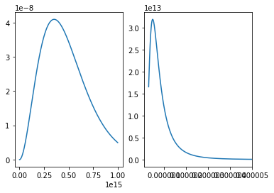

```python
%matplotlib inline

import numpy as np
import matplotlib.pyplot as plt
import scipy as sp
import scipy.integrate as integrate
import scipy.constants as cont


C = cont.c
K = cont.k
H = cont.h

def Bf(f, T):
    bf = (C**2)*np.expm1((H*f)/(K*T))
    return 2.0*H*(f**3) / bf


def Bw(w, T):
    bw = (w**5)*np.expm1((H*C)/(w*K*T))
    return 2.0*H*(C**2) / bw

def uf(f, T):
    return (4*np.pi*Bf(f, T))/C

def uw(w, T):
    return (4*np.pi*Bw(w, T))/C


T = 6000

f = np.linspace(1e10, 1e15, 10000)
wavelength = C / f

plt.figure()
plt.subplot(121)
plt.plot(f,Bf(f,T))


plt.subplot(122)
plt.plot(wavelength, Bw(wavelength, T))
plt.xlim([1e-7, 5e-6])
```

##### Energy density

$$\frac{U}{V} = \int_{0}^{\infty} u_{\nu}(\nu, T) d\nu = \int_{0}^{\infty} \frac{8\pi h \nu^3}{c^3} \frac{1}{e^{\frac{h\nu}{kT}}-1} d\nu = \frac{4\sigma T^4}{c}$$

令 $ x = \frac{h\nu}{kT} $，故 $dx = \frac{h}{kT} d\nu$ $$\frac{U}{V} = \frac{8\pi (kT)^4}{(hc)^3} \int_{0}^{\infty} \frac{x^3}{e^{x}-1} dx $$

此積分項稱Bose-Einstein integral, 可利用 Riemann zeta function $ \zeta (4)$ 與 Gamma function 求值： $$ J = \int_{0}^{\infty} \frac{x^3}{e^{x}-1} dx = \zeta(4) \Gamma(4) =\frac{\pi^4}{90} \times 6 =\frac{\pi^4}{15} $$

Riemann zeta function$: \zeta(s) = \sum_{n=1}^{\infty} \frac{1}{n^{s}}$

Gamma function: $ \Gamma(n) = \int_{0}^{\infty} \frac{x^{n-1}}{e^{x}} dx = (n-1) !$

故

$$\frac{U}{V} = \frac{8 \pi^5 (kT)^4}{15(hc)^3} =aT^4 $$

其中 $a$ 稱為radiation constant

$$ a = 7.56 \times 10^{-16} Jm^{-3}K^{-4}$$

## 計算過程

ref :林文隆，物理雙月刊（23卷2期）2001年4月，宇宙能量密度與黎曼$\zeta$函數

$$ \frac{1}{e^{x}-1} = \frac{1}{e^{x} \left( 1-e^{-x} \right) } = e^{-x} \left( 1+e^{-x}+e^{-2x}+ \cdots \right) = \sum_{n=1}^{\infty} e^{-nx}$$$$ J = \int_{0}^{\infty} \frac{x^3}{e^{x}-1} dx = \sum_{n=1}^{\infty} \int_{0}^{\infty}e^{-nx} x^{3} dx$$

adopt integration by part

$$ \int_{0}^{\infty}e^{-nx} x^{3} dx = \frac{3}{n}\int_{0}^{\infty}e^{-nx} x^{2} dx = \frac{3 \cdot 2}{n^2}\int_{0}^{\infty}e^{-nx} x dx =\frac{3 \cdot 2 \cdot 1}{n^3}\int_{0}^{\infty}e^{-nx} dx = \frac{3!}{n^{3}} \times \frac{1}{n} = \frac{3!}{n^4}$$

$$ \therefore J=3! \sum_{n=1}^{\infty} \frac{1}{n^4} = 3! \zeta \left( 4 \right)$$

黎曼$\zeta$函數： $$\zeta(s) = \sum_{n=1}^{\infty} \frac{1}{n^{s}} $$

當$s>1$時函數收斂。當$s$為偶數時，可利用傅立葉級數求值：

$$ x^{2} = \frac{\pi^2}{3} + 4 \sum_{1}^{\infty} (-1)^{n} \frac{\cos nx}{n^2}$$$$ x^{4} = \frac{\pi^4}{5} + \sum_{1}^{\infty} (-1)^{n} \left( \frac{8\pi^2}{n^2} - \frac{48}{n^4} \right) \cos nx$$

令 $x = \pi $ 代入上兩式， $$ \pi^2 = \frac{\pi^2}{3} + 4 \sum_{1}^{\infty} \frac{1}{n^2} \Rightarrow \zeta(2)= \sum_{1}^{\infty} \frac{1}{n^2}= \frac{\pi^2}{6}$$

$$ \frac{4}{5} \pi^4 = 8 \pi^2 \zeta(2) - 48 \zeta(4) \Rightarrow \zeta(4) = \frac{\pi^4}{90}$$

所以，

$$J = 3! \zeta \left( 4 \right) = \frac{\pi^4}{15}$$

或是利用Parseval's identity:

f(x)之傅立葉級數為 $$ f(x) = \frac{a_{0}}{2} + \sum_{1}^{\infty}a_{n}\cos nx + \sum_{1}^{\infty}b_{n} \sin nx ，(-\pi<x<\pi)$$

Parseval's identity $$ \frac{1}{\pi} \int_{-\pi}^{\pi} \lbrack f(x) \rbrack^{2} dx = \frac{{a_{0}}^{2}}{2} + \sum_{1}^{\infty} \left( {a_{n}}^2 + {b_{n}}^2 \right)$$

令$f(x)=x^2$代入，且已知各係數值 $a_{0}= \frac{2}{3}\pi^2$，$a_{n}=\frac{4(-1)^n}{n^2}$

$$ \frac{1}{\pi} \int_{-\pi}^{\pi} \lbrack x^2 \rbrack^{2} dx = \frac{(\frac{2}{3}\pi^2)^2}{2} + \sum_{1}^{\infty} (-1)^{2n}\frac{16}{n^4}$$$$\frac{1}{\pi} \frac{x^5}{5} \bracevert_{-\pi}^{\pi}= \frac{2}{5}\pi^4 = \frac{2}{9}\pi^4 + \sum_{1}^{\infty} \frac{16}{n^4} \Rightarrow \zeta(4) = \frac{\pi^4}{90} $$

##### Stefan-Boltzmann law:

The Stefan–Boltzmann law gives the power emitted per unit area of the emitting body,

$$\frac{P}{A} = \int_{0}^{\infty} B_{\nu}(\nu, T)d\nu \int d\Omega$$

Lambert's cosine law: the intensity observed along the sphere will be the actual intensity times the cosine of the zenith angle φ,

$$\frac{P}{A} =\int_{0}^{\infty} B_{\nu}(\nu, T)d\nu \int_{0}^{2\pi} d\theta \int_{0}^{\frac{\pi}{2}} \cos \phi \sin \phi d\phi = \pi \int_{0}^{\infty} B_{\nu}(\nu, T)d\nu = \frac{c}{4} \frac{U}{V} = \sigma T^{4} $$$$\sigma = \frac{2\pi^5 k^4}{15c^2 h ^3} = \frac{ac}{4} = 5.67\times 10^{-8} Js^{-1}m^{-2}K^{-4}$$

## 單位體積的光子數量

$$ n = \int_{0}^{\infty} \frac{u_{\nu}(\nu, T)}{h\nu} d\nu = \int_{0}^{\infty} \frac{8\pi \nu^2}{c^3} \frac{1}{e^{\frac{h\nu}{kT}}-1} d\nu $$

令$ x = \frac{h\nu}{kT} $，故 $dx = \frac{h}{kT} d\nu$ $$\frac{N}{V} = \frac{8\pi (kT)^3}{(hc)^3} \int_{0}^{\infty} \frac{x^2}{e^{x}-1} dx $$

積分項：

$$ N = \int_{0}^{\infty} \frac{x^2}{e^{x}-1} dx = \sum_{n=1}^{\infty} \int_{0}^{\infty}e^{-nx} x^{2} dx $$$$ \int_{0}^{\infty}e^{-nx} x^{2} dx = \frac{2}{n}\int_{0}^{\infty}e^{-nx} x dx = \frac{2 \cdot 1}{n^2}\int_{0}^{\infty}e^{-nx} dx = \frac{2!}{n^{2}} \times \frac{1}{n} = \frac{2!}{n^3}$$

故$$N = 2 \times \zeta(3)$$

而 $\zeta(3)\approx 1.202 $，所以$N \approx 2.404$

$$ n = \frac{8\pi (kT)^3}{(hc)^3} \times 2.404 \approx 20.2 T^3 photons/cm^3 $$

宇宙微波背景輻射的溫度$T=2.7$K， 故$$n(T=2.7K) \approx 400 photons/cm^3$$

```python
# 積分求 a 與 sigma
# 設定溫度時，不要太低，否則積分誤差大，積分上下限也需要調整

%matplotlib inline

import numpy as np
import matplotlib.pyplot as plt
import scipy as sp
from scipy.integrate import quad
import scipy.constants as cont

C = cont.c
K = cont.k
H = cont.h
Temp = 1000

def Bf(f, T):
    return 2.0 * H * (f**3) / (C * C* np.expm1( (H*f) / (K*T) ))

def uf(f, T):
    return (4 * np.pi * Bf(f, T)) /C

def BfT(f):
    #Temp = 1000
    return Bf(f, Temp)

def ufT(f):
    #Temp = 1000
    return uf(f, Temp)


lower_bound = 0
upper_bound = 1E+15

ans, err = quad(ufT, lower_bound, upper_bound)
ansp = 0.25 * C * ans
ans2, err2 = quad(BfT, lower_bound, upper_bound)

a = ans / (Temp**4)
a_err = err / (Temp**4)

sigma =  np.pi * ans2 / (Temp**4)
sigma_err =  np.pi * err2 / (Temp**4)

print('a =', a, '+-', a_err)
print('sigma =', sigma, '+-' , sigma_err)
```

```
a = 7.565723105793764e-16 +- 9.992838517307925e-24
sigma = 5.670366816083266e-08 +- 7.489444024465403e-16
```

## 相對論性費米子的能量密度與數量密度

光子的能量分佈函數遵守Bose-Einstein distribution $$f_{B}= \frac{1}{e^{E/kT}-1}$$ 而對於半整數自旋的費米子，其能量分佈函數為Fermi-Dirac distribution，

$$f_{f}= \frac{1}{e^{E/kT}+1}$$

故計算費米子的能量密度時，會有 $$ u_{f} = a T^4 \int_{0}^{\infty} \frac{x^3}{e^{x}+1}dx$$ 其中$$J_{F}=\int_{0}^{\infty} \frac{x^3}{e^{x}+1}dx $$ 又設$J_{B}=\int_{0}^{\infty} \frac{x^3}{e^{x}-1}dx $ $$ \Rightarrow J_{B}-J_{F}= \int_{0}^{\infty} \frac{2x^3}{e^{2x}-1} dx $$

令$y=2x$，則

$$ J_{B}-J_{F}= \frac{1}{8} \int_{0}^{\infty} \frac{y^3}{e^{y}-1} dy = \frac{1}{8}J_{B}$$$$ \Rightarrow J_{F}=\frac{7}{8}J_{B} $$

推廣：

$$ \int_{0}^{\infty} \frac{x^n}{e^{x}+1} dx = \left( 1- \frac{1}{2^n} \right) \int_{0}^{\infty} \frac{x^n}{e^{x}-1} dx $$

故$$ N_{F}=\int_{0}^{\infty} \frac{x^2}{e^{x}+1}dx ，N_{B}=\int_{0}^{\infty} \frac{x^2}{e^{x}-1}dx \Rightarrow N_{F}=\frac{3}{4}N_{B}$$

所以，

- 相對論性波色子、光子能量密度 $u_{B}=aT^{4}$

  相對論性費米子能量密度 $u_{F}= \frac{7}{8}u_{B}= \frac{7}{8}aT^4$
- 相對論性波色子、光子數量密度 $n_{B}=bT^{3}$

  相對論性費米子能量密度 $n_{F}= \frac{3}{4}n_{B}= \frac{3}{4}bT^3$

# 解常微分方程

#### integrate.ode

$$\frac{dy}{dt}= f(t,y)$$

`from scipy.integrate import odeint`

`scipy.integrate.ode(f, jac=None)`

jac = $\frac{df}{dy}$ Jacobian `jac[i,j] = d f[i] / d y[j]`

http://sam-dolan.staff.shef.ac.uk/mas212/notebooks/ODE_Example.html

#### solve_ivp (較新的函數套件)

`from scipy.integrate import solve_ivp`

$$ \frac{dy}{dx}+y = x，y(0) = 1 $$$$\Rightarrow y = x -1 + 2 e^{-x}$$

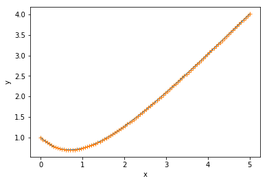

```python
from scipy.integrate import odeint

# Define a function which calculates the derivative
def dy_dx(y, x): #後項為要積的變數
    return x - y

xs = np.linspace(0,5,100)

y0 = 1.0  # the initial condition
ys = odeint(dy_dx, y0, xs)
#ys = np.array(ys).flatten()

# Plot the numerical solution
#plt.rcParams.update({'font.size': 14})  # increase the font size
plt.xlabel("x")
plt.ylabel("y")
#plt.plot(xs, ys)

y_exact = xs - 1 + 2*np.exp(-xs)
y_difference = ys - y_exact
plt.plot(xs, ys, xs, y_exact, "+")


#y_diff = np.abs(y_exact - ys)
#plt.semilogy(xs, y_diff)
#plt.ylabel("Error")
#plt.xlabel("x")
#plt.title("Error in numerical integration");
# Note the logarithmic scale on the y-axis.
```

## 半衰期

$$\frac{dN}{dt} = - \lambda N ， N_{0}=N(t=0)=1 $$$$ N =N_{0}e^{-\lambda t} = N_{0}(\frac{1}{2})^{\frac{t}{\tau}}$$

ps:當經過一個半衰期 $\tau$ 時： $$ e^{-\lambda \tau} = \frac{1}{2} \Rightarrow \tau = \frac{\ln 2}{\lambda}$$

```
(0, 5)
```

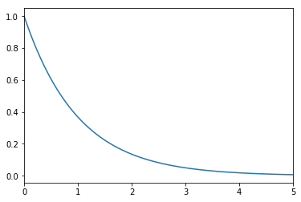

```python
import scipy.integrate as integarte
from scipy.integrate import odeint as ode
import numpy as np
import matplotlib.pyplot as plt

DT = 1
def fn(n, t): # fn = dn/dt = -dc*n
    dc = DT
    return (-dc*n)

initial = 1  # initial number

t = np.linspace(0, 5, 10000)  # time range
x = ode(fn, initial, t)
# ode(fn, initial condition, time)

plt.plot(t, x)
plt.xlim([0,5])
```

Suppose we have a second-order ODE such as a damped simple harmonic motion equation $$ y''+ 2y' + 2y = \cos(2x)，y(0)=0， y'(0)=0$$

define $ z =y'$，then we have $$ z'+ 2z + 2y = \cos(2x)，z(0)=y(0)=0 $$

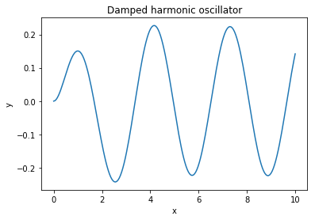

```python
%matplotlib inline

import scipy.integrate as integarte
from scipy.integrate import odeint as ode
import numpy as np
import matplotlib.pyplot as plt

def dU_dx(U, x):
    # Here U is a vector such that y=U[0] and z=U[1]. This function should return [y', z']
    return [U[1], -2*U[1] - 2*U[0] + np.cos(2*x)]

U0 = [0, 0]  # initial condition

xs = np.linspace(0, 10, 200)

Us = ode(dU_dx, U0, xs)
#print(Us)
ys = Us[:,0]
#print(ys)

plt.xlabel("x")
plt.ylabel("y")
plt.title("Damped harmonic oscillator")
plt.plot(xs,ys)
```

## SHM

$$ m \ddot{x} + b \dot{x} + kx = A \sin(x) $$$$ \Rightarrow \ddot{x} + \frac{b}{m} \dot{x} + \frac{k}{m}x = \frac{A}{m} \sin(x)$$

define $\omega_0 = \sqrt{\frac{k}{m}}，\omega_{b}=\sqrt{\frac{b}{2m}}，a = \frac{A}{m}$

$$ \ddot{x} + 2\omega_{b}^{2}\dot{x} +\omega_{0}^{2}x = a \sin(x)$$

let $ u=\dot{x}$, then

$$ \dot{u} + 2\omega_{b}^{2} u +\omega_{0}^{2}x = a \sin(x)$$

https://bob911017.github.io/nchu/pycourse.html#e3

https://gist.github.com/mick001/f4864f36551e89ab7bc4

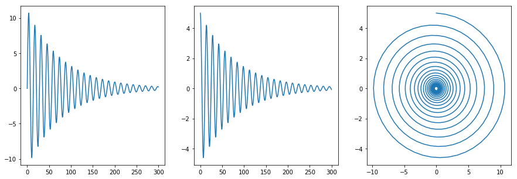

```python
import scipy.integrate as integarte
from scipy.integrate import odeint as ode
import numpy as np
import matplotlib.pyplot as plt

m = 5
k = 1
b = 0.01
A = 0.0

OM0 = np.sqrt(k/m)
OMb = np.sqrt(b/2*m)
a = A/m

IC = [0, 5] #initial condition=[x0(m),v0(m/s)]

def dU_dx(U,t):
    # x=U[0] and x'=u=U[1]. This function should return [x', u'=x'']
    return [U[1], (-(OMb**2)*U[1]-(OM0**2)*U[0]) + a*np.sin(U[0])]

t = np.linspace(0.0, 300.0, 1001) #(second)
U = ode(dU_dx, IC, t)  #odeint(function, intitial condition, time)


fig = plt.figure(figsize=(15,5))
ax0 = fig.add_subplot(131)
ax0.plot(t, U[:,0]) # x-t graph

ax1 = fig.add_subplot(132)
ax1.plot(t, U[:,1]) # v-t graph

ax2 = fig.add_subplot(133)
ax2.plot(U[:,0], U[:,1]) # phase diagram
```

# Solving ODE by finite difference method

## SHM:

$$\vec{a} = -\omega^{2} \vec{x}$$

設時間間隔為$\Delta t$ 的SHM物體連續三點位置座標：$x_{i-1}，x_{i}，x_{i+1}$ $$a = \lim_{\Delta t \rightarrow 0} \frac{v_{k+1}-v_{k}}{\Delta t}$$

其中 $$v_{k}=\lim_{\Delta t \rightarrow 0} \frac{x_{i}-x_{i-1}}{\Delta t}，v_{k+1}=\lim_{\Delta t \rightarrow 0} \frac{x_{i+1}-x_{i}}{\Delta t}$$

所以 $$a = \lim_{\Delta t \rightarrow 0} \frac{ \frac{x_{i+1}-x_{i}}{\Delta t}- \frac{x_{i}-x_{i-1}}{\Delta t}}{\Delta t}$$

$$\Rightarrow a = (x_{i+1}-2x_{i}+x_{i-1}) \Delta t^{-2} =\omega^{2}x_{i}$$$$\Rightarrow (x_{i+1}-2x_{i}+x_{i-1}) =- \omega^{2}\Delta t ^{2}x_{i}= - (\frac{2\pi \Delta t }{T})^{2}x_{i} $$

設 $T =2 \pi$， $\Delta t = 0.1 $

$$ (x_{i+1}-2x_{i}+x_{i-1}) =- 0.01 x_{i} \Rightarrow x_{i+1}=1.99x_{i}-x_{i-1}$$

得到位置的遞迴關係式，$ i \rightarrow i+1$ 時間間隔為$\Delta t =0.1$

設 $x_{0}=0，x_{1} = 0.1$，可由遞迴關係式得到各時間點的位置座標

## 採用solve_ivp

- 新的function
- This function numerically integrates a system of ordinary differential equations given an initial value

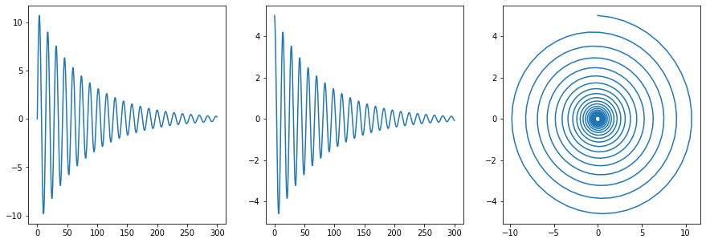

```python
import scipy as sp
from scipy.integrate import solve_ivp
import numpy as np
import matplotlib.pyplot as plt

m = 5
k = 1
b = 0.01
A = 0.0

OM0 = np.sqrt(k/m)
OMb = np.sqrt(b/2*m)
a = A/m

tf = 300
N = 1001


IC = [0, 5] #initial condition=[x0(m),v0(m/s)]

def dU_dt(t,U): # t在前
    # x=U[0] and x'=u=U[1]. This function should return [x', u'=x'']
    return [U[1], (-(OMb**2)*U[1]-(OM0**2)*U[0]) + a*np.sin(U[0])]


t = np.linspace(0.0, tf, N) #(second)
tspan = [0, tf]
U = solve_ivp(dU_dt, tspan, IC, t_eval=t)  #solve_ivp (function,  t_span, y0 )
#fun(t, y). Here t is a scalar, and there are two options for the ndarray y

fig = plt.figure(figsize=(15,5))
ax0 = fig.add_subplot(131)
ax0.plot(U.t, U.y[0]) # x-t graph

ax1 = fig.add_subplot(132)
ax1.plot(U.t, U.y[1]) # v-t graph

ax2 = fig.add_subplot(133)
ax2.plot(U.y[0], U.y[1]) # phase diagram
```

https://pundit.pratt.duke.edu/wiki/Python:Ordinary_Differential_Equations

EX: $$ \dfrac{dy(t)}{dt}=t-y(t) $$ initial value: $y(0)=2$

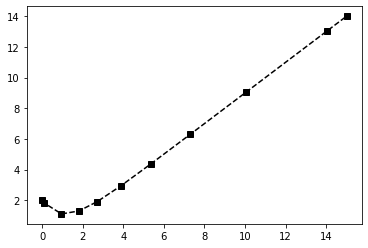

```python
from scipy.integrate import solve_ivp
sol = solve_ivp(lambda t, y: t-y, [0, 15], [2])
import matplotlib.pyplot as plt
plt.plot(sol.t, sol.y[0], 'k--s')
```

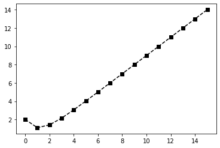

```python
from scipy.integrate import solve_ivp
import matplotlib.pyplot as plt

#if you want solutions at specific intermediate times, you can specify that with the t_eval kwarg:
sol = solve_ivp(lambda t, y: t-y, [0, 15], [2, 3],
                t_eval=np.linspace(0, 15, 16))

plt.plot(sol.t, sol.y[0], 'k--s')
```

$$ \dfrac{dy(t)}{dt} +\dfrac{y(t)}{4}=x(t) $$$$ \Rightarrow \dfrac{dy(t)}{dt} =x(t)-\dfrac{y(t)}{4} $$

Assume $x(t)=\cos(3t)$, $y(0)=-1$ you can numerically solve this differential equation (and plot the results for both $x(t)$ and $y(t)$) with:

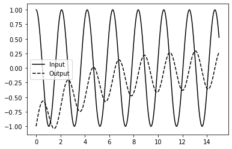

```python
%matplotlib inline
#  Imports
import numpy as np
import matplotlib.pyplot as plt
from scipy.integrate import solve_ivp

#  Define independent function and derivative function
def x(t):
    return np.cos(3 * t)

def f(t, y, c):
    dydt = x(t) - y / 4
    return dydt

#  Define time spans, initial values, and constants
tspan = np.linspace(0, 15, 1000)
yinit = [-1]
c = []

#  Solve differential equation
sol = solve_ivp(lambda t, y: f(t, y, c),
                [tspan[0], tspan[-1]], yinit, t_eval=tspan)

#  Plot independent and dependent variable
# Note that sol.y[0] is needed to extract a 1-D array
plt.figure(1)
plt.clf()
fig, ax = plt.subplots(num=1)
ax.plot(sol.t, x(sol.t), 'k-', label='Input')
ax.plot(sol.t, sol.y[0], 'k--', label='Output')
ax.legend(loc='best')
```

```
Text(0,0.5,'x position')
```

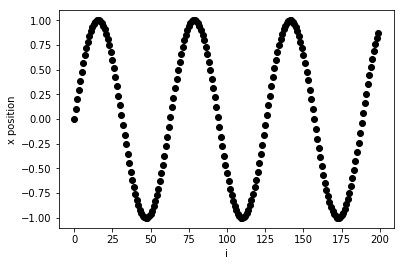

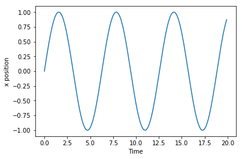

```python
%matplotlib inline

import numpy as np
import matplotlib.pyplot as plt

N= 200
dt = 0.1

ti = np.arange(N)
x = np.zeros(N)

x[0] = 0
x[1] = 0.1

for i in np.arange(1,N-1):
    x[i+1] = ((2 - dt**2)* x[i]) - x[i-1]

plt.figure()
plt.plot(ti , x, 'ko')
plt.xlabel('i')
plt.ylabel('x position')

plt.figure()
plt.plot(ti*dt, x)
plt.xlabel('Time')
plt.ylabel('x position')
```

# 擬合 fitting

`from scipy.optimize import curve_fit`

Use non-linear least squares to fit a function, f, to data.

Assumes ydata = f(xdata, *params) + eps

`scipy.optimize.curve_fit(fn, xdata, ydata, p0=())`

fn : model function p0 : Initial guess for the parameters. If None, then the initial values will all be 1

return:

- popt : array

Optimal values for the parameters so that the sum of the squared residuals of f(xdata, *popt) - ydata is minimized

- pcov : 2d array

The estimated covariance of popt. The diagonals provide the variance of the parameter estimate. To compute one standard deviation errors on the parameters use perr = np.sqrt(np.diag(pcov)).

https://docs.scipy.org/doc/scipy/reference/generated/scipy.optimize.curve_fit.html

```
[7.20046487 0.6378907  7.24594197]
[[ 0.03319269 -0.33192687  0.55043137]
 [-0.33192687  3.54276085 -6.6217745 ]
 [ 0.55043137 -6.6217745  16.5962087 ]]
a = 7.20046487002625 +/- 0.18218859982795105
b = 0.6378906991932354 +/- 1.8822223176125201
c = 7.2459419671264875 +/- 4.073844461948453
```

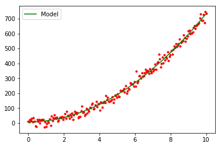

```python
%matplotlib inline

from scipy.optimize import curve_fit
import numpy as np
import matplotlib.pyplot as plt

A = 7.
B = 3.
C = 1.

# create data with noise
x = np.linspace(0, 10, 200)
y_data = A * x**2 + B *x + C + 20*np.random.randn(200)
plt.plot(x, y_data, 'r.')

def model(x, a, b, c):
     return a * x**2 + b *x + c

popt, pcov = curve_fit(model, x, y_data)
print(popt)
print(pcov)

perr = np.sqrt(np.diag(pcov)) # 取出pcov對角值再開根號

print("a =", popt[0], "+/-", perr[0])
print("b =", popt[1], "+/-", perr[1])
print("c =", popt[2], "+/-", perr[2])

plt.plot(x, model(x, popt[0], popt[1], popt[2]), 'g-', label='Model')

plt.legend()
```

```
[ 49.5774848    2.49858497 100.46235223]
[[ 3.09197262e-01 -1.01956156e-04  7.99037542e-03]
 [-1.01956156e-04  3.87903753e-06 -1.06318333e-04]
 [ 7.99037542e-03 -1.06318333e-04  1.53778120e-01]]
Amplitude = 49.577484798751705 +/- 0.5560550890655395
Period = 2.4985849724551246 +/- 0.0019695272351473695
DC = 100.46235223030368 +/- 0.3921455341321212
```

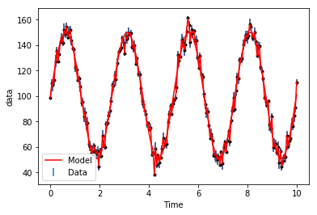

```python
%matplotlib inline

from scipy.optimize import curve_fit
import numpy as np
import matplotlib.pyplot as plt

# create data with noise
time = np.linspace(0, 10, 200)
data = 50 * np.sin(2 * np.pi / 2.5 * time) + 100  +  np.random.normal(0, 5., len(time))
plt.plot(time, data, 'k.')

data_err = 4 * np.random.rand(len(time)) + 1
plt.errorbar(time, data, yerr=data_err, fmt="r")


def model(time, amplitude, period, dc):
    return amplitude * np.sin(2 * np.pi / period * time) + dc

popt, pcov = curve_fit(model, time, data,  p0=[50, 2.5, 100], sigma=data_err)

print(popt)
print(pcov)

perr = np.sqrt(np.diag(pcov))

print("Amplitude =", popt[0], "+/-", perr[0])
print("Period =", popt[1], "+/-", perr[1])
print("DC =", popt[2], "+/-", perr[2])

plt.errorbar(time, data, yerr=data_err, fmt="none", label='Data')
plt.plot(time, model(time, popt[0], popt[1], popt[2]),'r-', label='Model')
plt.xlabel('Time')
plt.ylabel('data')
plt.legend(loc='best')
```